# eda

Libraries import

```python
import pandas as pd
import matplotlib.pyplot as plt
import seaborn as sns
```

Loaded the data.csv file for analysis and showed the first 5 rows.

```python
df = pd.read_csv('data.csv')
df.head()
```

|  | Invoice ID | Branch | City | Customer type | Gender | Product line | Unit price | Quantity | Tax 5% | Sales | Date | Time | Payment | cogs | gross margin percentage | gross income | Rating |
| --- | --- | --- | --- | --- | --- | --- | --- | --- | --- | --- | --- | --- | --- | --- | --- | --- | --- |
| 0 | 750-67-8428 | Alex | Yangon | Member | Female | Health and beauty | 74.69 | 7 | 26.1415 | 548.9715 | 1/5/2019 | 1:08:00 PM | Ewallet | 522.83 | 4.761905 | 26.1415 | 9.1 |
| 1 | 226-31-3081 | Giza | Naypyitaw | Normal | Female | Electronic accessories | 15.28 | 5 | 3.8200 | 80.2200 | 3/8/2019 | 10:29:00 AM | Cash | 76.40 | 4.761905 | 3.8200 | 9.6 |
| 2 | 631-41-3108 | Alex | Yangon | Normal | Female | Home and lifestyle | 46.33 | 7 | 16.2155 | 340.5255 | 3/3/2019 | 1:23:00 PM | Credit card | 324.31 | 4.761905 | 16.2155 | 7.4 |
| 3 | 123-19-1176 | Alex | Yangon | Member | Female | Health and beauty | 58.22 | 8 | 23.2880 | 489.0480 | 1/27/2019 | 8:33:00 PM | Ewallet | 465.76 | 4.761905 | 23.2880 | 8.4 |
| 4 | 373-73-7910 | Alex | Yangon | Member | Female | Sports and travel | 86.31 | 7 | 30.2085 | 634.3785 | 2/8/2019 | 10:37:00 AM | Ewallet | 604.17 | 4.761905 | 30.2085 | 5.3 |

showed the mean and other statistical stuff.

```python
df.describe()
```

|  | Unit price | Quantity | Tax 5% | Sales | cogs | gross margin percentage | gross income | Rating |
| --- | --- | --- | --- | --- | --- | --- | --- | --- |
| count | 1000.000000 | 1000.000000 | 1000.000000 | 1000.000000 | 1000.00000 | 1000.000000 | 1000.000000 | 1000.00000 |
| mean | 55.672130 | 5.510000 | 15.379369 | 322.966749 | 307.58738 | 4.761905 | 15.379369 | 6.97270 |
| std | 26.494628 | 2.923431 | 11.708825 | 245.885335 | 234.17651 | 0.000000 | 11.708825 | 1.71858 |
| min | 10.080000 | 1.000000 | 0.508500 | 10.678500 | 10.17000 | 4.761905 | 0.508500 | 4.00000 |
| 25% | 32.875000 | 3.000000 | 5.924875 | 124.422375 | 118.49750 | 4.761905 | 5.924875 | 5.50000 |
| 50% | 55.230000 | 5.000000 | 12.088000 | 253.848000 | 241.76000 | 4.761905 | 12.088000 | 7.00000 |
| 75% | 77.935000 | 8.000000 | 22.445250 | 471.350250 | 448.90500 | 4.761905 | 22.445250 | 8.50000 |
| max | 99.960000 | 10.000000 | 49.650000 | 1042.650000 | 993.00000 | 4.761905 | 49.650000 | 10.00000 |

```python
df.info()
```

```
<class 'pandas.core.frame.DataFrame'>
RangeIndex: 1000 entries, 0 to 999
Data columns (total 17 columns):
 #   Column                   Non-Null Count  Dtype
---  ------                   --------------  -----
 0   Invoice ID               1000 non-null   object
 1   Branch                   1000 non-null   object
 2   City                     1000 non-null   object
 3   Customer type            1000 non-null   object
 4   Gender                   1000 non-null   object
 5   Product line             1000 non-null   object
 6   Unit price               1000 non-null   float64
 7   Quantity                 1000 non-null   int64
 8   Tax 5%                   1000 non-null   float64
 9   Sales                    1000 non-null   float64
 10  Date                     1000 non-null   object
 11  Time                     1000 non-null   object
 12  Payment                  1000 non-null   object
 13  cogs                     1000 non-null   float64
 14  gross margin percentage  1000 non-null   float64
 15  gross income             1000 non-null   float64
 16  Rating                   1000 non-null   float64
dtypes: float64(7), int64(1), object(9)
memory usage: 132.9+ KB
```

Get the sum of the null entries.

```python
df.isnull().sum()
```

```
Invoice ID                 0
Branch                     0
City                       0
Customer type              0
Gender                     0
Product line               0
Unit price                 0
Quantity                   0
Tax 5%                     0
Sales                      0
Date                       0
Time                       0
Payment                    0
cogs                       0
gross margin percentage    0
gross income               0
Rating                     0
dtype: int64
```

Dropped the null entries.

```python
df = df.dropna()
```

Checked the names of the columns.

```python
df.columns
df.head()
```

|  | Invoice ID | Branch | City | Customer type | Gender | Product line | Unit price | Quantity | Tax 5% | Sales | Date | Time | Payment | cogs | gross margin percentage | gross income | Rating |
| --- | --- | --- | --- | --- | --- | --- | --- | --- | --- | --- | --- | --- | --- | --- | --- | --- | --- |
| 0 | 750-67-8428 | Alex | Yangon | Member | Female | Health and beauty | 74.69 | 7 | 26.1415 | 548.9715 | 1/5/2019 | 1:08:00 PM | Ewallet | 522.83 | 4.761905 | 26.1415 | 9.1 |
| 1 | 226-31-3081 | Giza | Naypyitaw | Normal | Female | Electronic accessories | 15.28 | 5 | 3.8200 | 80.2200 | 3/8/2019 | 10:29:00 AM | Cash | 76.40 | 4.761905 | 3.8200 | 9.6 |
| 2 | 631-41-3108 | Alex | Yangon | Normal | Female | Home and lifestyle | 46.33 | 7 | 16.2155 | 340.5255 | 3/3/2019 | 1:23:00 PM | Credit card | 324.31 | 4.761905 | 16.2155 | 7.4 |
| 3 | 123-19-1176 | Alex | Yangon | Member | Female | Health and beauty | 58.22 | 8 | 23.2880 | 489.0480 | 1/27/2019 | 8:33:00 PM | Ewallet | 465.76 | 4.761905 | 23.2880 | 8.4 |
| 4 | 373-73-7910 | Alex | Yangon | Member | Female | Sports and travel | 86.31 | 7 | 30.2085 | 634.3785 | 2/8/2019 | 10:37:00 AM | Ewallet | 604.17 | 4.761905 | 30.2085 | 5.3 |

Checked the count of the sold products according to their category.

```python
df['Product line'].value_counts()
```

```
Product line
Fashion accessories       178
Food and beverages        174
Electronic accessories    170
Sports and travel         166
Home and lifestyle        160
Health and beauty         152
Name: count, dtype: int64
```

Ploted the graph of the product categories.

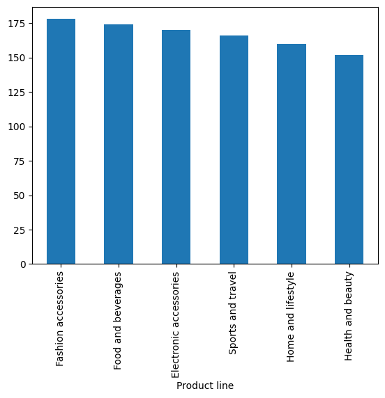

```python
df['Product line'].value_counts().plot(kind='bar')
plt.show()
```

Checked the frequency of the sales.

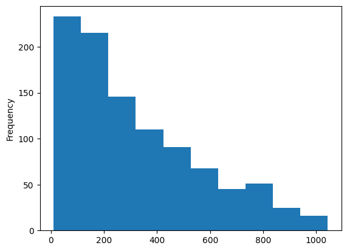

```python
df['Sales'].plot(kind='hist')
plt.show()
```

Heat map to show the correleation between the data.

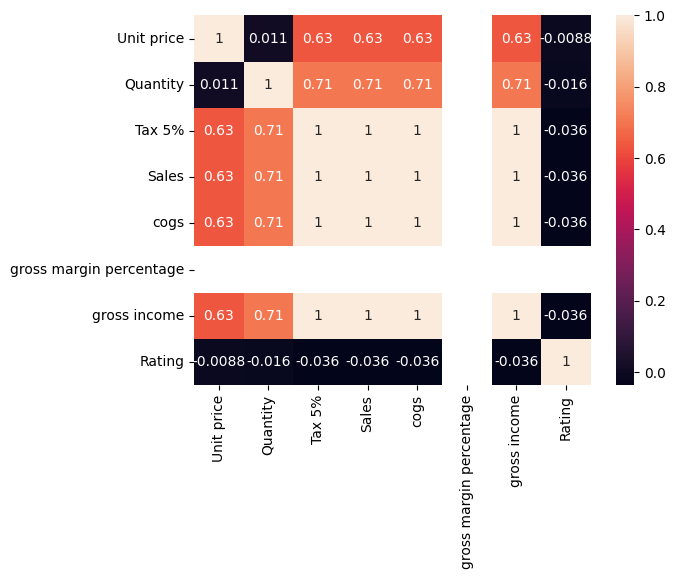

```python
sns.heatmap(df.corr(numeric_only=True), annot=True)
plt.show()
```

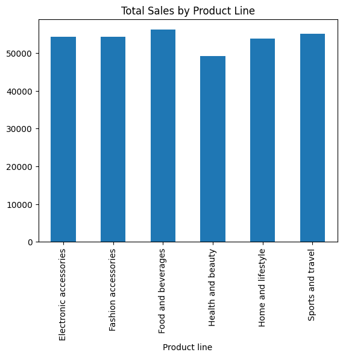

```python
df.groupby('Product line')['Sales'].sum().plot(kind='bar')
plt.title("Total Sales by Product Line")
plt.show()
```

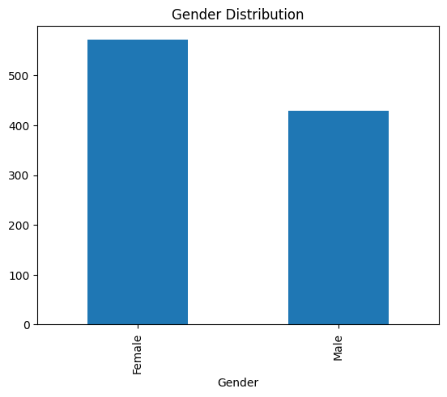

```python
df['Gender'].value_counts().plot(kind='bar')
plt.title("Gender Distribution")
plt.show()
```

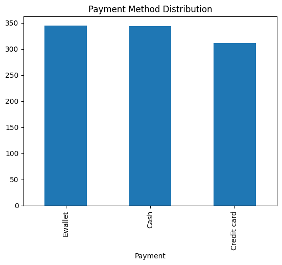

```python
df['Payment'].value_counts().plot(kind='bar')
plt.title("Payment Method Distribution")
plt.show()
```

Coclusion: Fashion & accessories have the most sales followed by food & beverages. The sales histogram is right skewed which means that the low cost products have been sold more than the high cost products. Generated more revenue with the food and beverages. Most of the products have been sold to female than males. And Ewallet and Cash were mostly equally used for transactions dominating Credit cards.

Machine Learning

Predict total sales amount based on input features which means If I know the quantity and unit price, can I predict how much the sale will be?

```python
X = df[['Quantity', 'Tax 5%', 'Unit price']]
y = df['Sales']
```

```python
from sklearn.model_selection import train_test_split

X_train, X_test, y_train, y_test = train_test_split(X, y, test_size=0.2)
```

```python
from sklearn.linear_model import LinearRegression

model = LinearRegression()
model.fit(X_train, y_train)
```

```
LinearRegression()
```

```python
predictions = model.predict(X_test)
```

```python
from sklearn.metrics import mean_absolute_error

mean_absolute_error(y_test, predictions)
```

```
9.283240842705709e-14
```

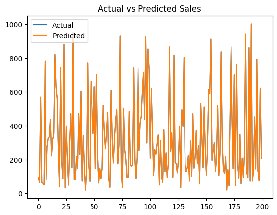

```python
plt.figure()

plt.plot(y_test.values, label='Actual')
plt.plot(predictions, label='Predicted')

plt.legend()
plt.title("Actual vs Predicted Sales")
plt.show()
```

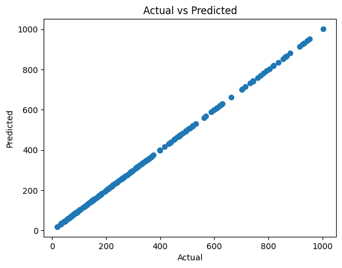

```python
plt.figure()

plt.scatter(y_test, predictions)
plt.xlabel("Actual")
plt.ylabel("Predicted")
plt.title("Actual vs Predicted")

plt.show()
```

Predict Customer Rating Now model tries to learn:

What influences customer satisfaction?

```python
y = df['Rating']
X = df[['Quantity', 'Unit price', 'Sales']]
```

```python
from sklearn.model_selection import train_test_split

X_train, X_test, y_train, y_test = train_test_split(X, y, test_size=0.2)
```

```python
from sklearn.linear_model import LinearRegression

model = LinearRegression()
model.fit(X_train, y_train)
```

```
LinearRegression()
```

```python
predictions = model.predict(X_test)
```

```python
from sklearn.metrics import mean_absolute_error
mean_absolute_error(y_test, predictions)
```

```
1.4242902279489422
```

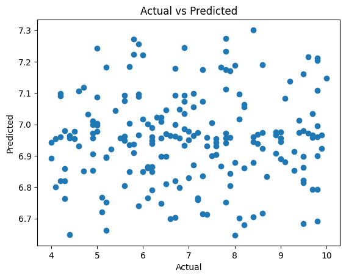

```python
plt.figure()

plt.scatter(y_test, predictions)
plt.xlabel("Actual")
plt.ylabel("Predicted")
plt.title("Actual vs Predicted")

plt.show()
```

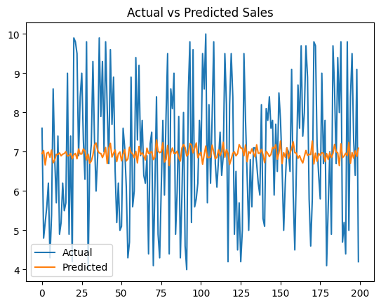

```python
plt.figure()

plt.plot(y_test.values, label='Actual')
plt.plot(predictions, label='Predicted')

plt.legend()
plt.title("Actual vs Predicted Sales")
plt.show()
```

Not a perfect model. Trying another model

```python
df_encoded = pd.get_dummies(df, drop_first=True)
```

```python
X = df_encoded.drop('Rating', axis=1)
y = df_encoded['Rating']
```

```python
from sklearn.ensemble import RandomForestRegressor

model = RandomForestRegressor()
model.fit(X_train, y_train)
```

```
RandomForestRegressor()
```

```python
predictions = model.predict(X_test)
```

```python
from sklearn.metrics import mean_absolute_error
mean_absolute_error(y_test, predictions)
```

```
1.4858239999999998
```

Didnt go well as well

Lets do time series forecasting

```python
daily_sales = df.groupby('Date')['Sales'].sum()
```

```python
df.isnull().sum()
```

[output not shown]

```python
daily_sales = daily_sales.sort_index()
```

```python
daily_sales.index
```

```
Index(['1/1/2019', '1/10/2019', '1/11/2019', '1/12/2019', '1/13/2019',
       '1/14/2019', '1/15/2019', '1/16/2019', '1/17/2019', '1/18/2019',
       '1/19/2019', '1/2/2019', '1/20/2019', '1/21/2019', '1/22/2019',
       '1/23/2019', '1/24/2019', '1/25/2019', '1/26/2019', '1/27/2019',
       '1/28/2019', '1/29/2019', '1/3/2019', '1/30/2019', '1/31/2019',
       '1/4/2019', '1/5/2019', '1/6/2019', '1/7/2019', '1/8/2019', '1/9/2019',
       '2/1/2019', '2/10/2019', '2/11/2019', '2/12/2019', '2/13/2019',
       '2/14/2019', '2/15/2019', '2/16/2019', '2/17/2019', '2/18/2019',
       '2/19/2019', '2/2/2019', '2/20/2019', '2/21/2019', '2/22/2019',
       '2/23/2019', '2/24/2019', '2/25/2019', '2/26/2019', '2/27/2019',
       '2/28/2019', '2/3/2019', '2/4/2019', '2/5/2019', '2/6/2019', '2/7/2019',
       '2/8/2019', '2/9/2019', '3/1/2019', '3/10/2019', '3/11/2019',
       '3/12/2019', '3/13/2019', '3/14/2019', '3/15/2019', '3/16/2019',
       '3/17/2019', '3/18/2019', '3/19/2019', '3/2/2019', '3/20/2019',
       '3/21/2019', '3/22/2019', '3/23/2019', '3/24/2019', '3/25/2019',
       '3/26/2019', '3/27/2019', '3/28/2019', '3/29/2019', '3/3/2019',
       '3/30/2019', '3/4/2019', '3/5/2019', '3/6/2019', '3/7/2019', '3/8/2019',
       '3/9/2019'],
      dtype='object', name='Date')
```

```python
df['Date'] = pd.to_datetime(df['Date'])
```

```python
df = df.set_index('Date')
```

```python
daily_sales = df['Sales'].resample('D').sum()
```

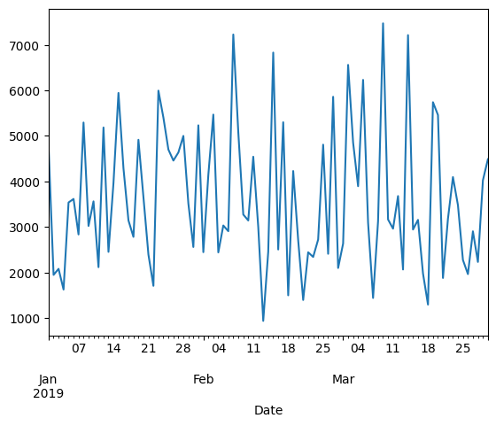

```python
daily_sales.plot()
plt.show()
```

```python
daily_sales.head()
```

```
Date
2019-01-01    4745.1810
2019-01-02    1945.5030
2019-01-03    2078.1285
2019-01-04    1623.6885
2019-01-05    3536.6835
Freq: D, Name: Sales, dtype: float64
```

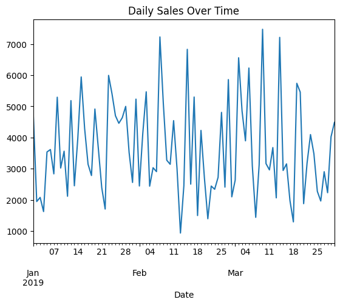

```python
daily_sales.plot()
plt.title("Daily Sales Over Time")
plt.show()
```

The Graph is random bcs of small amount of data however I will do the forecasting anyway...

```python
from statsmodels.tsa.arima.model import ARIMA
```

```python
model = ARIMA(daily_sales, order=(5,1,0))
model_fit = model.fit()
```

```python
forecast = model_fit.forecast(steps=10)
```

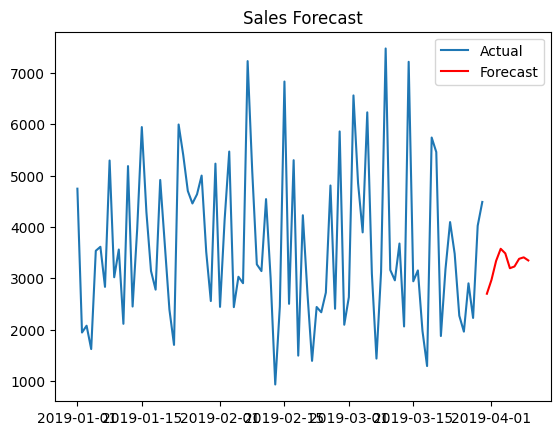

```python
plt.figure()

plt.plot(daily_sales, label='Actual')
plt.plot(forecast, label='Forecast', color='red')

plt.legend()
plt.title("Sales Forecast")
plt.show()
```

The forecast converges toward an average value, indicating that in the absence of strong patterns, the model predicts a stable mean level of sales

Conclusion

The time series analysis shows that daily sales exhibit high variability with no clear trend or seasonal pattern. As a result, the ARIMA model produces a relatively stable forecast centered around the mean sales value. This suggests that sales are largely driven by random fluctuations rather than predictable temporal patterns.